# Estimation and Variable Selection

Inter-American Development Bank Workshop

Diego A. Guerrero

2025-11-26

# Learning Objectives

- Apply Least Angle Regression (LARS) for data-driven variable pre-selection in a high-dimensional context.
- Use Principal Component Analysis (PCA) for dimensionality reduction.
- Apply the nowcasting environment (ragged edges, missing value) to a data series
- Estimate a simple nowcasting with OLS model

# The Dataset

**N=359** variables with **T = 165** periods.

```python
import pandas as pd
df = pd.read_csv('session_3_files/data_full.csv', index_col='date', parse_dates=True)
print(df.shape)
df.head(2)
```

```
(165, 359)
```

| date | XIMP1001 | XIMP1002 | XIMP1003 | XIMP1004 | XIMP1005 | XIMP1006 | XIMP1007 | XIMP1008 | XIMP1009 | XIMP1010 | ... | UNTL9305 | UNTL9306 | UNTL9307 | UNTL9308 | UNTL9309 | UNTL9310 | UNTL9100 | UNTL9101 | UNTL9300 | UNTL9301 |
| --- | --- | --- | --- | --- | --- | --- | --- | --- | --- | --- | --- | --- | --- | --- | --- | --- | --- | --- | --- | --- | --- |
| 2012-01-01 | NaN | NaN | NaN | NaN | NaN | NaN | NaN | NaN | NaN | NaN | ... | 1733.413031 | 2333.054790 | 9196.965173 | 11608.406551 | 403271.120527 | 39739.857455 | 6397.754096 | 160.855881 | 115954.087427 | 1781.034760 |
| 2012-02-01 | NaN | NaN | NaN | NaN | NaN | NaN | NaN | NaN | NaN | NaN | ... | 2195.223720 | 1747.708021 | 9425.924103 | 14279.820776 | 537522.811678 | 34611.790605 | 6186.863317 | 154.792484 | 148960.086790 | 1952.801482 |

2 rows × 359 columns

## Variable Selection

- *Everything but the kitchen sink* $\rightarrow$ overfitting. Noisy estimates have poor out of sample performance.
- The literature has long supported human-driven variable choices
- Economists use institutional knowledge to choose aggregate demand and aggregate supply factors.
- We build and expand on Chinn et al (2023)’s data-driven approach exploiting Least-Angle Regression to select variables.

## Least Angle Regression (LARS) intuition

Efron et al. (2004) propose LARS to fit high-dimensional data:

1. Set all coefficients $\beta=0$
2. Find $x_{j}$ with the largest correlation with $y$
3. Increase $\beta_{j}$ in the direction of the correlation. Estimate $r=y-\hat{y}$.
4. Stop when you find $x_{k}$ with as much correlation with $r$ as $x_{j}$
5. Increase $\beta_{j}, \beta_{k}$ until some variable $x_{m}$ has more correlation with $r$
6. Increase $\beta_{j}, \beta_{k}, \beta_{m}$ until some predictor $x_{n}$ has more correlation with $r$.
7. Continue until all predictors are included.

## LARS for variable selection

- Define a train/test dataset
- Estimate OLS with all variables using 5 PCA factors. Estimate RMSE in test data.
- Run LARS to select $n$ variables
- Compute 5 PCA factors for the $n$ LARS-selected variables
- Estimate OLS with the 5 factors from the $n$ LARS-selected variables. Estimate RMSE in test data.
- Compare RMSE from full-OLS and LARS-OLS

## Our LARS help function

```python
def lars_variable_ranking(df, target, max_vars=None, test = None , factors = 5 ):
    """
    Stepwise LARS variable selection: rank variables by their entry into the model.
    - df: DataFrame with predictors and target
    - target: name of the target variable
    - max_vars: number of variables to select; if None, continue until all are ranked
    Returns:
    - selected_vars: ordered list of variable names by entry into the LARS model

    Chinn, M. D., Meunier, B., & Stumpner, S. (2023). Nowcasting world trade with machine learning: a three-step approach (No. w31419). National Bureau of Economic Research.
    """
    data = deepcopy(df)

    selected_order = []
    count = 0
    max_vars = max_vars or (df.shape[1] - 1)

    while count < max_vars:
        X = data.drop(columns=[target])
        y = data[target]

        # Stop if no variables remain
        if X.shape[1] == 0 : break

        # Fit LARS model
        model = Lars(n_nonzero_coefs=X.shape[1], jitter=0 , random_state=0)
        model.fit(X, y)

        # coef_path_ has shape (n_features, n_steps)
        coef_path = np.array(model.coef_path_)
        # Count how many times each variable is zero
        zero_counts = (coef_path == 0).sum(axis=1)

        # Summary table
        out = pd.DataFrame({'Variable': X.columns, 'ZeroCount': zero_counts})
        out = out.sort_values('ZeroCount')

        # Take variables that are uniquely at this ZeroCount level
        grouped = out.groupby('ZeroCount')
        selected = grouped.filter(lambda g: len(g) == 1)

        # If nothing uniquely enters, dump all remaining vars
        if selected.empty:
            remaining = X.columns.tolist() # Take all remaining variables
            selected = pd.DataFrame({'Variable': remaining, 'ZeroCount': [count]*len(remaining)})
            selected_order.extend(remaining) # Add them to the selected_order list
            print("Warning: Using fallback procedure for LARS")
            break
        else:
            selected_vars = selected['Variable'].tolist()
            selected_order.extend(selected_vars)

            # Drop selected vars from future batches
            data = data.drop(columns=selected_vars)
            count += len(selected_vars)
    top_vars = selected_order[:max_vars]
    if test is None :
        return top_vars, None
    else :
        data = deepcopy(df)
        data = pd.concat([data, test], axis=0)
        data = data[ [target] + top_vars]

        X = pd.DataFrame(scaler.fit_transform(data.drop(target, axis=1)))
        X = X.dropna(axis=1)
        pca = PCA(n_components=factors)

        X = pca.fit_transform(X)
        X = pd.DataFrame(X)
        X.rename(columns=lambda x: f'PC_{x}', inplace=True)
        X.index = data.index

        data = pd.concat( [ data[[target]] , X ] ,axis=1)

        test = data[data.index >= test.index.min()]
        data = data[data.index < test.index.min()]

        X_train = data[X.columns]
        y_train = data[target]

        X_test = test[X.columns]
        y_test = test[target]

        final_model = LinearRegression()
        final_model.fit(X_train, y_train)
        y_pred = final_model.predict(X_test)
        rmse = np.mean( (y_test - y_pred)**2 )

        return top_vars , rmse
```

# The Nowcasting Environment

## Information windows

Economic data is typically not available until weeks or months have passed.

Nowcasting is an estimation method that looks to overcome publication lags.

In a given time, we have an information set that depends on the publication lags in each dataset.

## Metadata

Excel file with details on each variable: ticket, real/nominal value, block (DFM specific), and **monthly publication lag**

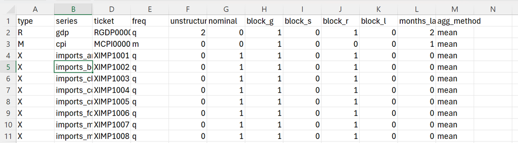

## Simulating an information window

```python
import numpy as np
metadata = pd.read_csv('session_3_files/meta_full.csv')
def gen_lagged_data(metadata, data, last_date, lag):
    # only go up to the last date
    lagged_data = data.loc[data.date <= last_date, :].reset_index(drop=True)
    for col in lagged_data.columns[1:]:
        pub_lag = metadata.loc[metadata.ticket == col, "months_lag"].values[0]
        lagged_data.loc[(len(lagged_data) - pub_lag + lag ) :, col] = np.nan

    return lagged_data
test = df[df.index<"2023-01-01"].reset_index(drop=False)
test = gen_lagged_data(metadata, test, "2023-01-01", -2)
test.set_index('date')[["UNTL3100", "UGTR1000", "RARR0000", "MRES0000"]].tail(5)
```

| date | UNTL3100 | UGTR1000 | RARR0000 | MRES0000 |
| --- | --- | --- | --- | --- |
| 2022-08-01 | NaN | 34.426230 | 619928.0 | 3268069.0 |
| 2022-09-01 | 5889.886184 | 32.442623 | 467354.0 | 3199668.0 |
| 2022-10-01 | 5635.023023 | 33.524590 | NaN | 3025454.0 |
| 2022-11-01 | NaN | NaN | NaN | NaN |
| 2022-12-01 | NaN | NaN | NaN | NaN |

## PCA Factors

Principal Component Analysis (PCA) linearly transforms data onto a new coordinate system such that the directions (principal components) captures the largest variation in the data.

```python
print(f"Raw dimensions: {df.shape}")
df = df.fillna(df.mean(numeric_only=True))

from sklearn.decomposition import PCA
from sklearn.preprocessing import StandardScaler
scaler = StandardScaler()

X = pd.DataFrame(scaler.fit_transform(df.drop("RGDP0000", axis=1)))
X = X.dropna(axis=1)
pca = PCA(n_components=3)

X = pca.fit_transform(X)
X = pd.DataFrame(X)
X.rename(columns=lambda x: f'PC_{x}', inplace=True)
print(f"PCA dimensions: {X.shape}")
X.tail(5)
```

```
Raw dimensions: (165, 359)
PCA dimensions: (165, 3)
```

|  | PC_0 | PC_1 | PC_2 |
| --- | --- | --- | --- |
| 160 | -0.553463 | 1.961716 | 5.810487 |
| 161 | -0.410306 | 1.715587 | 5.955141 |
| 162 | -0.541942 | 1.670347 | 7.458588 |
| 163 | -0.468904 | 1.150023 | 6.422522 |
| 164 | -0.557188 | 1.740699 | 7.139590 |

## Data Flattening

Flattening solves a mixed frequencies issue by transforming dates within a quarter into columns.

```python
def flatten_data(data, target_variable, n_lags):
    flattened_data = data.loc[~pd.isna(data[target_variable]), :]
    orig_index = flattened_data.index
    for i in range(1, n_lags + 1):
        lagged_indices = orig_index - i
        lagged_indices = lagged_indices[lagged_indices >= 0]
        tmp = data.loc[lagged_indices, :]
        tmp.date = tmp.date + pd.DateOffset(months=i)
        tmp = tmp.drop([target_variable], axis=1)
        tmp.columns = [j + "_" + str(i) if j != "date" else j for j in tmp.columns]
        flattened_data = flattened_data.merge(tmp, how="left", on="date")

    return flattened_data

transformed_train = pd.concat( [ df.reset_index(drop=False)[['date', "RGDP0000"]] , X ] ,axis=1)
transformed_train = flatten_data(transformed_train, "RGDP0000", 3 ).set_index('date')
transformed_train.head(4)
```

| date | RGDP0000 | PC_0 | PC_1 | PC_2 | PC_0_1 | PC_1_1 | PC_2_1 | PC_0_2 | PC_1_2 | PC_2_2 | PC_0_3 | PC_1_3 | PC_2_3 |
| --- | --- | --- | --- | --- | --- | --- | --- | --- | --- | --- | --- | --- | --- |
| 2012-01-01 | 3009.410526 | -0.391592 | 1.268363 | 2.469966 | NaN | NaN | NaN | NaN | NaN | NaN | NaN | NaN | NaN |
| 2012-02-01 | 3009.410526 | -0.500201 | 2.317809 | 5.854962 | -0.391592 | 1.268363 | 2.469966 | NaN | NaN | NaN | NaN | NaN | NaN |
| 2012-03-01 | 3009.410526 | -0.496562 | 1.842651 | 5.935667 | -0.500201 | 2.317809 | 5.854962 | -0.391592 | 1.268363 | 2.469966 | NaN | NaN | NaN |
| 2012-04-01 | 3009.410526 | -0.482002 | 1.731524 | 6.518290 | -0.496562 | 1.842651 | 5.935667 | -0.500201 | 2.317809 | 5.854962 | -0.391592 | 1.268363 | 2.469966 |

## OLS Estimation

Two additional data cleaning steps: (1) Fill missing values with the mean, (2) Keep only quarters.

Then we can estimate a model.

This is a Nowcast because data has been prepared to simulate publication lags rather than assume full information.

```python
from sklearn.linear_model import LinearRegression
transformed_train = transformed_train.fillna(transformed_train.mean(numeric_only=True))
transformed_train = transformed_train.resample('QS').last()
model = LinearRegression()
x = transformed_train.drop(["RGDP0000"], axis=1)
y = transformed_train["RGDP0000"]
model.fit(x, y)
```

```
LinearRegression()
```

## Looping

The full process is included within several loops. What do we loop?

```python
for date in dates :

    # Transform Data
    # Run PCA
    # Model Estimation with a function:
    ols_fit, ols_vars = fit_ols(
            transformed_train ,
            gdp_lags = 2,
            flat_lags = 3
        )
    # Loop different publication lags for each test period
    for lag in lags:
        pred_ols = predict_ols(
            model=ols_fit,
            X = tmp_data ,
            train_vars = ols_vars,
            date = date,
            l = lag,
            pred_dict = pred_ols ,
            flat_lags = 3 ,
            gdp_lags = 2,
            )
    # Save results
    performance_table = pd.concat( [ performance_table , perform_tab(pred_ols, "OLS", spec , actuals) ], axis=0)
    result_table = pd.concat( [ result_table , forecast_table(pred_ols, "OLS", spec , actuals, dates) ], axis=0)
```

# A complete program

- Complete program: more involved. Within the **previous loop**, the algorithm runs **additional estimators**.
- **A loop to rule them all:** We run all of LARS top models + different specifications (flattening, lags, PCA).

# Activity

The activity increased in complexity. We will run `notebook_3.ipynb` together.

The program will:

1. Perform LARS for variable selection
2. Choose one set of variables
3. Transform and clean the data in preparation to Nowcast
4. Nowcast GDP with OLS in three information windows
5. Estimate accuracy measures